> **Tip**: Welcome to the Investigate a Dataset project! You will find tips in quoted sections like this to help organize your approach to your investigation. Before submitting your project, it will be a good idea to go back through your report and remove these sections to make the presentation of your work as tidy as possible. First things first, you might want to double-click this Markdown cell and change the title so that it reflects your dataset and investigation.

# Project: Investigate a Dataset (FBI Gun Data)

- Introduction
- Data Wrangling
- Exploratory Data Analysis
- Conclusions

## Introduction

> **Tip**: In this section of the report, provide a brief introduction to the dataset you've selected for analysis. At the end of this section, describe the questions that you plan on exploring over the course of the report. Try to build your report around the analysis of at least one dependent variable and three independent variables. If you're not sure what questions to ask, then make sure you familiarize yourself with the dataset, its variables and the dataset context for ideas of what to explore.

> If you haven't yet selected and downloaded your data, make sure you do that first before coming back here. In order to work with the data in this workspace, you also need to upload it to the workspace. To do so, click on the jupyter icon in the upper left to be taken back to the workspace directory. There should be an 'Upload' button in the upper right that will let you add your data file(s) to the workspace. You can then click on the .ipynb file name to come back here.

```python
# import necessary liberaries
import numpy as np
import pandas as pd
import matplotlib.pyplot as plt
import seaborn as sns
% matplotlib inline
```

## Data Wrangling

> **Tip**: In this section of the report, you will load in the data, check for cleanliness, and then trim and clean your dataset for analysis. Make sure that you document your steps carefully and justify your cleaning decisions.

### General Properties

```python
# Read the files
df1 = pd.read_excel("gun-data.xlsx")
df2 = pd.read_csv("u.s.-census-data.csv")
```

### "gun-data.xlsx" which stored in df1

```python
df1.head(10)
```

|  | month | state | permit | permit_recheck | handgun | long_gun | other | multiple | admin | prepawn_handgun | ... | returned_other | rentals_handgun | rentals_long_gun | private_sale_handgun | private_sale_long_gun | private_sale_other | return_to_seller_handgun | return_to_seller_long_gun | return_to_seller_other | totals |
| --- | --- | --- | --- | --- | --- | --- | --- | --- | --- | --- | --- | --- | --- | --- | --- | --- | --- | --- | --- | --- | --- |
| 0 | 2017-09 | Alabama | 16717.0 | 0.0 | 5734.0 | 6320.0 | 221.0 | 317 | 0.0 | 15.0 | ... | 0.0 | 0.0 | 0.0 | 9.0 | 16.0 | 3.0 | 0.0 | 0.0 | 3.0 | 32019 |
| 1 | 2017-09 | Alaska | 209.0 | 2.0 | 2320.0 | 2930.0 | 219.0 | 160 | 0.0 | 5.0 | ... | 0.0 | 0.0 | 0.0 | 17.0 | 24.0 | 1.0 | 0.0 | 0.0 | 0.0 | 6303 |
| 2 | 2017-09 | Arizona | 5069.0 | 382.0 | 11063.0 | 7946.0 | 920.0 | 631 | 0.0 | 13.0 | ... | 0.0 | 0.0 | 0.0 | 38.0 | 12.0 | 2.0 | 0.0 | 0.0 | 0.0 | 28394 |
| 3 | 2017-09 | Arkansas | 2935.0 | 632.0 | 4347.0 | 6063.0 | 165.0 | 366 | 51.0 | 12.0 | ... | 0.0 | 0.0 | 0.0 | 13.0 | 23.0 | 0.0 | 0.0 | 2.0 | 1.0 | 17747 |
| 4 | 2017-09 | California | 57839.0 | 0.0 | 37165.0 | 24581.0 | 2984.0 | 0 | 0.0 | 0.0 | ... | 0.0 | 0.0 | 0.0 | 0.0 | 0.0 | 0.0 | 0.0 | 0.0 | 0.0 | 123506 |
| 5 | 2017-09 | Colorado | 4356.0 | 0.0 | 15751.0 | 13448.0 | 1007.0 | 1062 | 0.0 | 0.0 | ... | 1.0 | 0.0 | 0.0 | 0.0 | 0.0 | 0.0 | 0.0 | 0.0 | 0.0 | 35873 |
| 6 | 2017-09 | Connecticut | 4343.0 | 673.0 | 4834.0 | 1993.0 | 274.0 | 0 | 0.0 | 0.0 | ... | 0.0 | 0.0 | 0.0 | 0.0 | 0.0 | 0.0 | 0.0 | 0.0 | 0.0 | 12117 |
| 7 | 2017-09 | Delaware | 275.0 | 0.0 | 1414.0 | 1538.0 | 66.0 | 68 | 0.0 | 0.0 | ... | 0.0 | 0.0 | 0.0 | 55.0 | 34.0 | 3.0 | 1.0 | 2.0 | 0.0 | 3502 |
| 8 | 2017-09 | District of Columbia | 1.0 | 0.0 | 56.0 | 4.0 | 0.0 | 0 | 0.0 | 0.0 | ... | 0.0 | 0.0 | 0.0 | 0.0 | 0.0 | 0.0 | 0.0 | 0.0 | 0.0 | 61 |
| 9 | 2017-09 | Florida | 10784.0 | 0.0 | 39199.0 | 17949.0 | 2319.0 | 1721 | 1.0 | 18.0 | ... | 0.0 | 0.0 | 0.0 | 11.0 | 9.0 | 0.0 | 0.0 | 1.0 | 0.0 | 77390 |

10 rows × 27 columns

```python
df1.info()
```

```
<class 'pandas.core.frame.DataFrame'>
RangeIndex: 12485 entries, 0 to 12484
Data columns (total 27 columns):
month                        12485 non-null object
state                        12485 non-null object
permit                       12461 non-null float64
permit_recheck               1100 non-null float64
handgun                      12465 non-null float64
long_gun                     12466 non-null float64
other                        5500 non-null float64
multiple                     12485 non-null int64
admin                        12462 non-null float64
prepawn_handgun              10542 non-null float64
prepawn_long_gun             10540 non-null float64
prepawn_other                5115 non-null float64
redemption_handgun           10545 non-null float64
redemption_long_gun          10544 non-null float64
redemption_other             5115 non-null float64
returned_handgun             2200 non-null float64
returned_long_gun            2145 non-null float64
returned_other               1815 non-null float64
rentals_handgun              990 non-null float64
rentals_long_gun             825 non-null float64
private_sale_handgun         2750 non-null float64
private_sale_long_gun        2750 non-null float64
private_sale_other           2750 non-null float64
return_to_seller_handgun     2475 non-null float64
return_to_seller_long_gun    2750 non-null float64
return_to_seller_other       2255 non-null float64
totals                       12485 non-null int64
dtypes: float64(23), int64(2), object(2)
memory usage: 2.6+ MB
```

```python
df1.describe()
```

|  | permit | permit_recheck | handgun | long_gun | other | multiple | admin | prepawn_handgun | prepawn_long_gun | prepawn_other | ... | returned_other | rentals_handgun | rentals_long_gun | private_sale_handgun | private_sale_long_gun | private_sale_other | return_to_seller_handgun | return_to_seller_long_gun | return_to_seller_other | totals |
| --- | --- | --- | --- | --- | --- | --- | --- | --- | --- | --- | --- | --- | --- | --- | --- | --- | --- | --- | --- | --- | --- |
| count | 12461.000000 | 1100.000000 | 12465.000000 | 12466.000000 | 5500.000000 | 12485.000000 | 12462.000000 | 10542.000000 | 10540.000000 | 5115.000000 | ... | 1815.000000 | 990.000000 | 825.000000 | 2750.000000 | 2750.000000 | 2750.000000 | 2475.000000 | 2750.000000 | 2255.000000 | 12485.000000 |
| mean | 6413.629404 | 1165.956364 | 5940.881107 | 7810.847585 | 360.471636 | 268.603364 | 58.898090 | 4.828021 | 7.834156 | 0.165591 | ... | 1.027548 | 0.076768 | 0.087273 | 14.936000 | 11.602909 | 1.030182 | 0.402020 | 0.441818 | 0.105987 | 21595.725911 |
| std | 23752.338269 | 9224.200609 | 8618.584060 | 9309.846140 | 1349.478273 | 783.185073 | 604.814818 | 10.907756 | 16.468028 | 1.057105 | ... | 4.386296 | 0.634503 | 0.671649 | 71.216021 | 54.253090 | 4.467843 | 1.446568 | 1.528223 | 0.427363 | 32591.418387 |
| min | 0.000000 | 0.000000 | 0.000000 | 0.000000 | 0.000000 | 0.000000 | 0.000000 | 0.000000 | 0.000000 | 0.000000 | ... | 0.000000 | 0.000000 | 0.000000 | 0.000000 | 0.000000 | 0.000000 | 0.000000 | 0.000000 | 0.000000 | 0.000000 |
| 25% | 0.000000 | 0.000000 | 865.000000 | 2078.250000 | 17.000000 | 15.000000 | 0.000000 | 0.000000 | 0.000000 | 0.000000 | ... | 0.000000 | 0.000000 | 0.000000 | 0.000000 | 0.000000 | 0.000000 | 0.000000 | 0.000000 | 0.000000 | 4638.000000 |
| 50% | 518.000000 | 0.000000 | 3059.000000 | 5122.000000 | 121.000000 | 125.000000 | 0.000000 | 0.000000 | 1.000000 | 0.000000 | ... | 0.000000 | 0.000000 | 0.000000 | 0.000000 | 0.000000 | 0.000000 | 0.000000 | 0.000000 | 0.000000 | 12399.000000 |
| 75% | 4272.000000 | 0.000000 | 7280.000000 | 10380.750000 | 354.000000 | 301.000000 | 0.000000 | 5.000000 | 8.000000 | 0.000000 | ... | 0.000000 | 0.000000 | 0.000000 | 2.000000 | 4.000000 | 0.000000 | 0.000000 | 0.000000 | 0.000000 | 25453.000000 |
| max | 522188.000000 | 116681.000000 | 107224.000000 | 108058.000000 | 77929.000000 | 38907.000000 | 28083.000000 | 164.000000 | 269.000000 | 49.000000 | ... | 64.000000 | 12.000000 | 12.000000 | 1017.000000 | 777.000000 | 71.000000 | 28.000000 | 17.000000 | 4.000000 | 541978.000000 |

8 rows × 25 columns

```python
df1.duplicated().sum()
```

```
0
```

### "u.s.-census-data.csv" which stored in df2

```python
df2.head(10)
```

|  | Fact | Fact Note | Alabama | Alaska | Arizona | Arkansas | California | Colorado | Connecticut | Delaware | ... | South Dakota | Tennessee | Texas | Utah | Vermont | Virginia | Washington | West Virginia | Wisconsin | Wyoming |
| --- | --- | --- | --- | --- | --- | --- | --- | --- | --- | --- | --- | --- | --- | --- | --- | --- | --- | --- | --- | --- | --- |
| 0 | Population estimates, July 1, 2016, (V2016) | NaN | 4,863,300 | 741,894 | 6,931,071 | 2,988,248 | 39,250,017 | 5,540,545 | 3,576,452 | 952,065 | ... | 865454 | 6651194 | 27,862,596 | 3,051,217 | 624,594 | 8,411,808 | 7,288,000 | 1,831,102 | 5,778,708 | 585,501 |
| 1 | Population estimates base, April 1, 2010, (V2... | NaN | 4,780,131 | 710,249 | 6,392,301 | 2,916,025 | 37,254,522 | 5,029,324 | 3,574,114 | 897,936 | ... | 814195 | 6346298 | 25,146,100 | 2,763,888 | 625,741 | 8,001,041 | 6,724,545 | 1,853,011 | 5,687,289 | 563,767 |
| 2 | Population, percent change - April 1, 2010 (es... | NaN | 1.70% | 4.50% | 8.40% | 2.50% | 5.40% | 10.20% | 0.10% | 6.00% | ... | 0.063 | 0.048 | 10.80% | 10.40% | -0.20% | 5.10% | 8.40% | -1.20% | 1.60% | 3.90% |
| 3 | Population, Census, April 1, 2010 | NaN | 4,779,736 | 710,231 | 6,392,017 | 2,915,918 | 37,253,956 | 5,029,196 | 3,574,097 | 897,934 | ... | 814180 | 6346105 | 25,145,561 | 2,763,885 | 625,741 | 8,001,024 | 6,724,540 | 1,852,994 | 5,686,986 | 563,626 |
| 4 | Persons under 5 years, percent, July 1, 2016, ... | NaN | 6.00% | 7.30% | 6.30% | 6.40% | 6.30% | 6.10% | 5.20% | 5.80% | ... | 0.071 | 0.061 | 7.20% | 8.30% | 4.90% | 6.10% | 6.20% | 5.50% | 5.80% | 6.50% |
| 5 | Persons under 5 years, percent, April 1, 2010 | NaN | 6.40% | 7.60% | 7.10% | 6.80% | 6.80% | 6.80% | 5.70% | 6.20% | ... | 0.073 | 0.064 | 7.70% | 9.50% | 5.10% | 6.40% | 6.50% | 5.60% | 6.30% | 7.10% |
| 6 | Persons under 18 years, percent, July 1, 2016,... | NaN | 22.60% | 25.20% | 23.50% | 23.60% | 23.20% | 22.80% | 21.10% | 21.50% | ... | 0.246 | 0.226 | 26.20% | 30.20% | 19.00% | 22.20% | 22.40% | 20.50% | 22.30% | 23.70% |
| 7 | Persons under 18 years, percent, April 1, 2010 | NaN | 23.70% | 26.40% | 25.50% | 24.40% | 25.00% | 24.40% | 22.90% | 22.90% | ... | 0.249 | 0.236 | 27.30% | 31.50% | 20.70% | 23.20% | 23.50% | 20.90% | 23.60% | 24.00% |
| 8 | Persons 65 years and over, percent, July 1, 2... | NaN | 16.10% | 10.40% | 16.90% | 16.30% | 13.60% | 13.40% | 16.10% | 17.50% | ... | 0.16 | 0.157 | 12.00% | 10.50% | 18.10% | 14.60% | 14.80% | 18.80% | 16.10% | 15.00% |
| 9 | Persons 65 years and over, percent, April 1, 2010 | NaN | 13.80% | 7.70% | 13.80% | 14.40% | 11.40% | 10.90% | 14.20% | 14.40% | ... | 0.143 | 0.134 | 10.30% | 9.00% | 14.60% | 12.20% | 12.30% | 16.00% | 13.70% | 12.40% |

10 rows × 52 columns

```python
df2.info()
```

```
<class 'pandas.core.frame.DataFrame'>
RangeIndex: 85 entries, 0 to 84
Data columns (total 52 columns):
Fact              80 non-null object
Fact Note         28 non-null object
Alabama           65 non-null object
Alaska            65 non-null object
Arizona           65 non-null object
Arkansas          65 non-null object
California        65 non-null object
Colorado          65 non-null object
Connecticut       65 non-null object
Delaware          65 non-null object
Florida           65 non-null object
Georgia           65 non-null object
Hawaii            65 non-null object
Idaho             65 non-null object
Illinois          65 non-null object
Indiana           65 non-null object
Iowa              65 non-null object
Kansas            65 non-null object
Kentucky          65 non-null object
Louisiana         65 non-null object
Maine             65 non-null object
Maryland          65 non-null object
Massachusetts     65 non-null object
Michigan          65 non-null object
Minnesota         65 non-null object
Mississippi       65 non-null object
Missouri          65 non-null object
Montana           65 non-null object
Nebraska          65 non-null object
Nevada            65 non-null object
New Hampshire     65 non-null object
New Jersey        65 non-null object
New Mexico        65 non-null object
New York          65 non-null object
North Carolina    65 non-null object
North Dakota      65 non-null object
Ohio              65 non-null object
Oklahoma          65 non-null object
Oregon            65 non-null object
Pennsylvania      65 non-null object
Rhode Island      65 non-null object
South Carolina    65 non-null object
South Dakota      65 non-null object
Tennessee         65 non-null object
Texas             65 non-null object
Utah              65 non-null object
Vermont           65 non-null object
Virginia          65 non-null object
Washington        65 non-null object
West Virginia     65 non-null object
Wisconsin         65 non-null object
Wyoming           65 non-null object
dtypes: object(52)
memory usage: 34.6+ KB
```

```python
df2.duplicated().sum()
```

```
3
```

```python
df2[df2.Alaska.isnull()]       # there are many rows with NaN
```

|  | Fact | Fact Note | Alabama | Alaska | Arizona | Arkansas | California | Colorado | Connecticut | Delaware | ... | South Dakota | Tennessee | Texas | Utah | Vermont | Virginia | Washington | West Virginia | Wisconsin | Wyoming |
| --- | --- | --- | --- | --- | --- | --- | --- | --- | --- | --- | --- | --- | --- | --- | --- | --- | --- | --- | --- | --- | --- |
| 65 | NaN | NaN | NaN | NaN | NaN | NaN | NaN | NaN | NaN | NaN | ... | NaN | NaN | NaN | NaN | NaN | NaN | NaN | NaN | NaN | NaN |
| 66 | NOTE: FIPS Code values are enclosed in quotes ... | NaN | NaN | NaN | NaN | NaN | NaN | NaN | NaN | NaN | ... | NaN | NaN | NaN | NaN | NaN | NaN | NaN | NaN | NaN | NaN |
| 67 | NaN | NaN | NaN | NaN | NaN | NaN | NaN | NaN | NaN | NaN | ... | NaN | NaN | NaN | NaN | NaN | NaN | NaN | NaN | NaN | NaN |
| 68 | Value Notes | NaN | NaN | NaN | NaN | NaN | NaN | NaN | NaN | NaN | ... | NaN | NaN | NaN | NaN | NaN | NaN | NaN | NaN | NaN | NaN |
| 69 | 1 | Includes data not distributed by county. | NaN | NaN | NaN | NaN | NaN | NaN | NaN | NaN | ... | NaN | NaN | NaN | NaN | NaN | NaN | NaN | NaN | NaN | NaN |
| 70 | NaN | NaN | NaN | NaN | NaN | NaN | NaN | NaN | NaN | NaN | ... | NaN | NaN | NaN | NaN | NaN | NaN | NaN | NaN | NaN | NaN |
| 71 | Fact Notes | NaN | NaN | NaN | NaN | NaN | NaN | NaN | NaN | NaN | ... | NaN | NaN | NaN | NaN | NaN | NaN | NaN | NaN | NaN | NaN |
| 72 | (a) | Includes persons reporting only one race | NaN | NaN | NaN | NaN | NaN | NaN | NaN | NaN | ... | NaN | NaN | NaN | NaN | NaN | NaN | NaN | NaN | NaN | NaN |
| 73 | (b) | Hispanics may be of any race, so also are incl... | NaN | NaN | NaN | NaN | NaN | NaN | NaN | NaN | ... | NaN | NaN | NaN | NaN | NaN | NaN | NaN | NaN | NaN | NaN |
| 74 | (c) | Economic Census - Puerto Rico data are not com... | NaN | NaN | NaN | NaN | NaN | NaN | NaN | NaN | ... | NaN | NaN | NaN | NaN | NaN | NaN | NaN | NaN | NaN | NaN |
| 75 | NaN | NaN | NaN | NaN | NaN | NaN | NaN | NaN | NaN | NaN | ... | NaN | NaN | NaN | NaN | NaN | NaN | NaN | NaN | NaN | NaN |
| 76 | Value Flags | NaN | NaN | NaN | NaN | NaN | NaN | NaN | NaN | NaN | ... | NaN | NaN | NaN | NaN | NaN | NaN | NaN | NaN | NaN | NaN |
| 77 | - | Either no or too few sample observations were ... | NaN | NaN | NaN | NaN | NaN | NaN | NaN | NaN | ... | NaN | NaN | NaN | NaN | NaN | NaN | NaN | NaN | NaN | NaN |
| 78 | D | Suppressed to avoid disclosure of confidential... | NaN | NaN | NaN | NaN | NaN | NaN | NaN | NaN | ... | NaN | NaN | NaN | NaN | NaN | NaN | NaN | NaN | NaN | NaN |
| 79 | F | Fewer than 25 firms | NaN | NaN | NaN | NaN | NaN | NaN | NaN | NaN | ... | NaN | NaN | NaN | NaN | NaN | NaN | NaN | NaN | NaN | NaN |
| 80 | FN | Footnote on this item in place of data | NaN | NaN | NaN | NaN | NaN | NaN | NaN | NaN | ... | NaN | NaN | NaN | NaN | NaN | NaN | NaN | NaN | NaN | NaN |
| 81 | NaN | Not available | NaN | NaN | NaN | NaN | NaN | NaN | NaN | NaN | ... | NaN | NaN | NaN | NaN | NaN | NaN | NaN | NaN | NaN | NaN |
| 82 | S | Suppressed; does not meet publication standards | NaN | NaN | NaN | NaN | NaN | NaN | NaN | NaN | ... | NaN | NaN | NaN | NaN | NaN | NaN | NaN | NaN | NaN | NaN |
| 83 | X | Not applicable | NaN | NaN | NaN | NaN | NaN | NaN | NaN | NaN | ... | NaN | NaN | NaN | NaN | NaN | NaN | NaN | NaN | NaN | NaN |
| 84 | Z | Value greater than zero but less than half uni... | NaN | NaN | NaN | NaN | NaN | NaN | NaN | NaN | ... | NaN | NaN | NaN | NaN | NaN | NaN | NaN | NaN | NaN | NaN |

20 rows × 52 columns

> **Tip**: You should *not* perform too many operations in each cell. Create cells freely to explore your data. One option that you can take with this project is to do a lot of explorations in an initial notebook. These don't have to be organized, but make sure you use enough comments to understand the purpose of each code cell. Then, after you're done with your analysis, create a duplicate notebook where you will trim the excess and organize your steps so that you have a flowing, cohesive report.

> **Tip**: Make sure that you keep your reader informed on the steps that you are taking in your investigation. Follow every code cell, or every set of related code cells, with a markdown cell to describe to the reader what was found in the preceding cell(s). Try to make it so that the reader can then understand what they will be seeing in the following cell(s).

df1 has too much NaN, I will fill it with the mean

```python
# how to solve
df1.fillna(df1.mean(),inplace = True) # fill NaN values with the mean
# check our solution
df1.info()
```

```
<class 'pandas.core.frame.DataFrame'>
RangeIndex: 12485 entries, 0 to 12484
Data columns (total 27 columns):
month                        12485 non-null object
state                        12485 non-null object
permit                       12485 non-null float64
permit_recheck               12485 non-null float64
handgun                      12485 non-null float64
long_gun                     12485 non-null float64
other                        12485 non-null float64
multiple                     12485 non-null int64
admin                        12485 non-null float64
prepawn_handgun              12485 non-null float64
prepawn_long_gun             12485 non-null float64
prepawn_other                12485 non-null float64
redemption_handgun           12485 non-null float64
redemption_long_gun          12485 non-null float64
redemption_other             12485 non-null float64
returned_handgun             12485 non-null float64
returned_long_gun            12485 non-null float64
returned_other               12485 non-null float64
rentals_handgun              12485 non-null float64
rentals_long_gun             12485 non-null float64
private_sale_handgun         12485 non-null float64
private_sale_long_gun        12485 non-null float64
private_sale_other           12485 non-null float64
return_to_seller_handgun     12485 non-null float64
return_to_seller_long_gun    12485 non-null float64
return_to_seller_other       12485 non-null float64
totals                       12485 non-null int64
dtypes: float64(23), int64(2), object(2)
memory usage: 2.6+ MB
```

df2 has 3 duplicated rows

```python
# how to solve
df2.drop_duplicates(inplace = True)  # Drop the duplicated rows
# check our solution
df2.info()          # it is 82 entries instead of 85
```

```
<class 'pandas.core.frame.DataFrame'>
Int64Index: 82 entries, 0 to 84
Data columns (total 52 columns):
Fact              80 non-null object
Fact Note         28 non-null object
Alabama           65 non-null object
Alaska            65 non-null object
Arizona           65 non-null object
Arkansas          65 non-null object
California        65 non-null object
Colorado          65 non-null object
Connecticut       65 non-null object
Delaware          65 non-null object
Florida           65 non-null object
Georgia           65 non-null object
Hawaii            65 non-null object
Idaho             65 non-null object
Illinois          65 non-null object
Indiana           65 non-null object
Iowa              65 non-null object
Kansas            65 non-null object
Kentucky          65 non-null object
Louisiana         65 non-null object
Maine             65 non-null object
Maryland          65 non-null object
Massachusetts     65 non-null object
Michigan          65 non-null object
Minnesota         65 non-null object
Mississippi       65 non-null object
Missouri          65 non-null object
Montana           65 non-null object
Nebraska          65 non-null object
Nevada            65 non-null object
New Hampshire     65 non-null object
New Jersey        65 non-null object
New Mexico        65 non-null object
New York          65 non-null object
North Carolina    65 non-null object
North Dakota      65 non-null object
Ohio              65 non-null object
Oklahoma          65 non-null object
Oregon            65 non-null object
Pennsylvania      65 non-null object
Rhode Island      65 non-null object
South Carolina    65 non-null object
South Dakota      65 non-null object
Tennessee         65 non-null object
Texas             65 non-null object
Utah              65 non-null object
Vermont           65 non-null object
Virginia          65 non-null object
Washington        65 non-null object
West Virginia     65 non-null object
Wisconsin         65 non-null object
Wyoming           65 non-null object
dtypes: object(52)
memory usage: 34.0+ KB
```

df2 has many rows that has NAN

```python
# how to solve
df2.dropna(axis =0 ,subset=['Alaska', 'Alabama'],inplace = True) # Drop NaN values rows in Alaska and Alabama states
# check our solution
df2.info()
```

```
<class 'pandas.core.frame.DataFrame'>
Int64Index: 65 entries, 0 to 64
Data columns (total 52 columns):
Fact              65 non-null object
Fact Note         16 non-null object
Alabama           65 non-null object
Alaska            65 non-null object
Arizona           65 non-null object
Arkansas          65 non-null object
California        65 non-null object
Colorado          65 non-null object
Connecticut       65 non-null object
Delaware          65 non-null object
Florida           65 non-null object
Georgia           65 non-null object
Hawaii            65 non-null object
Idaho             65 non-null object
Illinois          65 non-null object
Indiana           65 non-null object
Iowa              65 non-null object
Kansas            65 non-null object
Kentucky          65 non-null object
Louisiana         65 non-null object
Maine             65 non-null object
Maryland          65 non-null object
Massachusetts     65 non-null object
Michigan          65 non-null object
Minnesota         65 non-null object
Mississippi       65 non-null object
Missouri          65 non-null object
Montana           65 non-null object
Nebraska          65 non-null object
Nevada            65 non-null object
New Hampshire     65 non-null object
New Jersey        65 non-null object
New Mexico        65 non-null object
New York          65 non-null object
North Carolina    65 non-null object
North Dakota      65 non-null object
Ohio              65 non-null object
Oklahoma          65 non-null object
Oregon            65 non-null object
Pennsylvania      65 non-null object
Rhode Island      65 non-null object
South Carolina    65 non-null object
South Dakota      65 non-null object
Tennessee         65 non-null object
Texas             65 non-null object
Utah              65 non-null object
Vermont           65 non-null object
Virginia          65 non-null object
Washington        65 non-null object
West Virginia     65 non-null object
Wisconsin         65 non-null object
Wyoming           65 non-null object
dtypes: object(52)
memory usage: 26.9+ KB
```

## Exploratory Data Analysis

> **Tip**: Now that you've trimmed and cleaned your data, you're ready to move on to exploration. Compute statistics and create visualizations with the goal of addressing the research questions that you posed in the Introduction section. It is recommended that you be systematic with your approach. Look at one variable at a time, and then follow it up by looking at relationships between variables.

### Research Question 1 (What state has high gun numbers per population estimates?)

```python
state = df1.groupby(["state"])
numerator = state.totals.mean() # The mean number of total gun per month grouped by each state
numerator
```

```
state
Alabama                  29542.198238
Alaska                    5011.643172
Arizona                  19496.537445
Arkansas                 16531.422907
California               83762.392070
Colorado                 26689.348018
Connecticut              13956.502203
Delaware                  2164.621145
District of Columbia        24.674009
Florida                  51523.246696
Georgia                  31761.859031
Guam                        66.066079
Hawaii                     870.396476
Idaho                     8670.193833
Illinois                 68156.537445
Indiana                  34084.458150
Iowa                     10119.629956
Kansas                   11562.418502
Kentucky                131112.044053
Louisiana                20727.123348
Maine                     5539.458150
Mariana Islands              2.035242
Maryland                  8967.629956
Massachusetts            11327.405286
Michigan                 31957.176211
Minnesota                27661.986784
Mississippi              15754.678414
Missouri                 28850.299559
Montana                   8300.105727
Nebraska                  5005.325991
Nevada                    7629.061674
New Hampshire             6974.220264
New Jersey                5047.779736
New Mexico                9147.977974
New York                 20457.392070
North Carolina           34262.947137
North Dakota              4173.744493
Ohio                     37280.810573
Oklahoma                 20195.832599
Oregon                   16524.497797
Pennsylvania             57858.484581
Puerto Rico                856.669604
Rhode Island              1272.555066
South Carolina           17684.722467
South Dakota              5355.559471
Tennessee                32208.339207
Texas                    85617.559471
Utah                     19111.334802
Vermont                   2134.127753
Virgin Islands              66.555066
Virginia                 25897.246696
Washington               28125.625551
West Virginia            14136.074890
Wisconsin                22606.718062
Wyoming                   3939.674009
Name: totals, dtype: float64
```

```python
denominator = df2.iloc[0][2:] # there is ',' we need to remove it
```

```python
denominator = df2.iloc[0][2:].str.replace(',','').astype(float) # Convert the string to float for division
denominator   # the population estimates for 2016
```

```
Alabama            4863300.0
Alaska              741894.0
Arizona            6931071.0
Arkansas           2988248.0
California        39250017.0
Colorado           5540545.0
Connecticut        3576452.0
Delaware            952065.0
Florida           20612439.0
Georgia           10310371.0
Hawaii             1428557.0
Idaho              1683140.0
Illinois          12801539.0
Indiana            6633053.0
Iowa               3134693.0
Kansas             2907289.0
Kentucky           4436974.0
Louisiana          4681666.0
Maine              1331479.0
Maryland           6016447.0
Massachusetts      6811779.0
Michigan           9928300.0
Minnesota          5519952.0
Mississippi        2988726.0
Missouri           6093000.0
Montana            1042520.0
Nebraska           1907116.0
Nevada             2940058.0
New Hampshire      1334795.0
New Jersey         8944469.0
New Mexico         2081015.0
New York          19745289.0
North Carolina    10146788.0
North Dakota        757952.0
Ohio              11614373.0
Oklahoma           3923561.0
Oregon             4093465.0
Pennsylvania      12784227.0
Rhode Island       1056426.0
South Carolina     4961119.0
South Dakota        865454.0
Tennessee          6651194.0
Texas             27862596.0
Utah               3051217.0
Vermont             624594.0
Virginia           8411808.0
Washington         7288000.0
West Virginia      1831102.0
Wisconsin          5778708.0
Wyoming             585501.0
Name: 0, dtype: float64
```

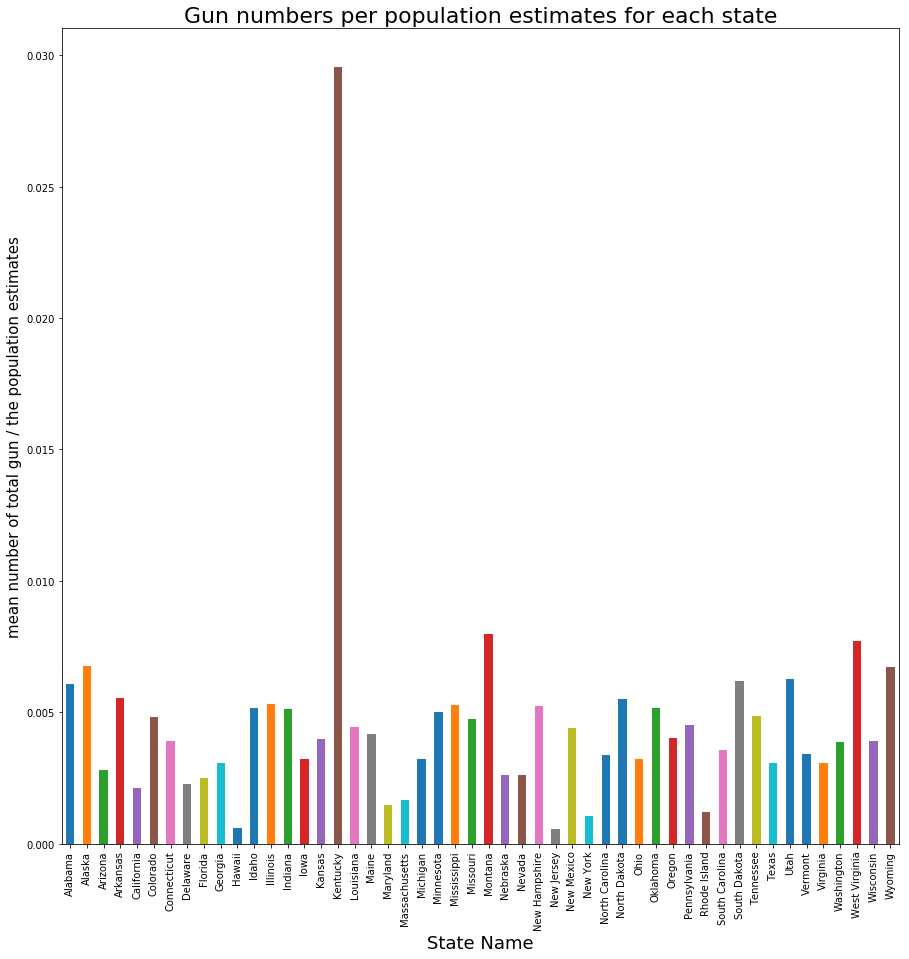

```python
guns = (numerator/denominator).dropna() # apply the division and drop NaN values
guns.plot(kind='bar', figsize=(15,15)); # Plot the result with bar chart
plt.xlabel('State Name',fontsize=18);
plt.ylabel('mean number of total gun / the population estimates',fontsize=15);
plt.title('Gun numbers per population estimates for each state',fontsize=22);
```

as we see "Kentucky" state is the most state that has guns per people there

### Research Question 2 (what is the gun type spreading out in each state?)

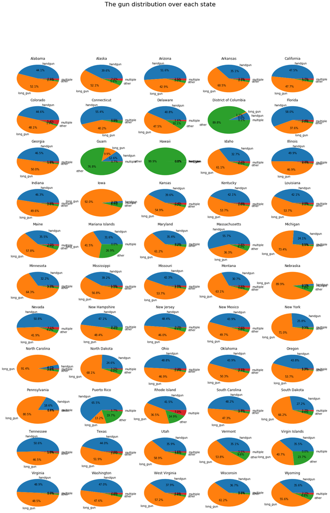

```python
fig,ax = plt.subplots(11, 5,figsize=(20,30))  # set the subplot for 25 slot to draw all states
fig.suptitle('The gun distribution over each state', fontsize=22)
k=0
j=0
lables = 'handgun','long_gun','other','multiple'
for i, row in state.mean().iterrows():
    if j%6==5:
        k = k+1 # to increment the row index after finishing the columns
        j=0     # reset the column index
    j=j+1
    ax[k,j-1].pie(row[['handgun','long_gun','other','multiple']],labels = lables,
                  autopct='%1.1f%%',radius=1)  # plot pie chart for each state
    ax[k,j-1].set(title=i)  # Set the title for each pie plot
```

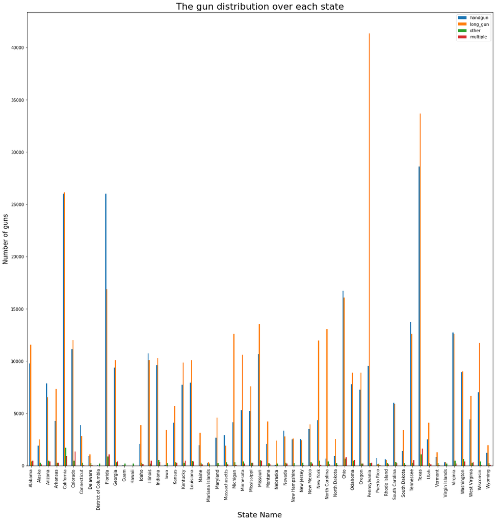

```python
state['handgun','long_gun','other','multiple'].mean().plot(kind='bar',figsize=(20,20)); # ohter way to represent with bar chart
plt.xlabel('State Name',fontsize=18);
plt.ylabel('Number of guns',fontsize=15);
plt.title('The gun distribution over each state',fontsize=22);
```

as we see the barchart shows the mean of any type of guns beside each other, So we can know what is the most common gun in this state, and we can repeat to know more about prepawn guns and redemption guns and so on

## Conclusions

> **Tip**: Finally, summarize your findings and the results that have been performed. Make sure that you are clear with regards to the limitations of your exploration. If you haven't done any statistical tests, do not imply any statistical conclusions. And make sure you avoid implying causation from correlation!

> **Tip**: Once you are satisfied with your work here, check over your report to make sure that it is satisfies all the areas of the rubric (found on the project submission page at the end of the lesson). You should also probably remove all of the "Tips" like this one so that the presentation is as polished as possible.

## Submitting your Project

> Before you submit your project, you need to create a .html or .pdf version of this notebook in the workspace here. To do that, run the code cell below. If it worked correctly, you should get a return code of 0, and you should see the generated .html file in the workspace directory (click on the orange Jupyter icon in the upper left).

> Alternatively, you can download this report as .html via the **File** > **Download as** submenu, and then manually upload it into the workspace directory by clicking on the orange Jupyter icon in the upper left, then using the Upload button.

> Once you've done this, you can submit your project by clicking on the "Submit Project" button in the lower right here. This will create and submit a zip file with this .ipynb doc and the .html or .pdf version you created. Congratulations!

# Summarization of my work

### Expolring the data

> It was the first stage I search for the missing values and the duplicated row, and try to search for some errors in the csv file or in xlsx file to try to fix them.

### Cleaning the data

> In this stage I suppose to clean the things I found in the previous stage, I fill the NaN values with the mean values in the gun-data.xlsx file and drop the NaN values in the u.s.-census-data.csv file because the NaN values was in the seme rows as the rows had too many NaN values, before drop it there was 3 duplicated rows I droped them then I droped the rows that has NaN

## Conclusion

```python
from subprocess import call
call(['python', '-m', 'nbconvert', 'Investigate_a_Dataset.ipynb'])
```

```
0
```